# mutation_spectrum

Arslan Zaidi

1/29/2019

```r
library(ggplot2)
library(data.table)
library(ape)
library(Biostrings)
library(ggrepel)
library(tidyr)
library(kableExtra)
library(circlize)
library(here)
library(kmer)
library(cowplot)
library(dplyr)
```

### Assign ‘ancestral’ state to heteroplasmies

To study the mutation spectrum, we needed to polarize the heteroplasmies, i.e., identify the ancestral/original and mutant states for each heteroplasmy. We do this by examining the frequency and allelic states across samples from the family.

First, we find heteroplasmies, which have the same major allele across all samples in the family. We can say with some confidence that these major alleles are likely the ancestral states of the heteroplasmy.

```r
#read allfam file with adjusted frequency added for allelic consistency across family members
allfam<-fread(here("Data_files/hq_counts_adj_frequency_09272018.txt"),header=T,sep="\t")

#separate heteroplasmies into a table
hq<-allfam%>%
  filter(heteroplasmy=="yes")

#determine the 'ancestral' and 'mutant' allele for each heteroplasmy

#determine if all family members have the same major allele in the family for a site
#if the major allele is the same, that's the 'ancestral' allele
hq.majors<-allfam%>%
  select(FID,position,major)%>%
  group_by(FID,position)%>%
  summarize(maj=paste(unique(major),collapse=","))%>%
  separate(maj,c("maj1","maj2"),sep=",")
#select rows where there is only one major allele
hq.major.1<-hq.majors%>%
  filter(is.na(maj2)=="TRUE")%>%
  mutate(fam_het_id=paste(FID,position,sep="_"))

##### assign 'ancestral' and 'mutant' alleles to hq
#for cases where the major allele is the same across families,
#the ancestral allele is the major allele and the mutant allele is the minor allele
hq.1<-hq%>%
  filter(fam_het_id%in%hq.major.1$fam_het_id)%>%
  mutate(ancestral=major)%>%
  mutate(mutant=minor)
```

Then we manually examine cases where the major allele is different across samples from the same family.

```r
#select rows where there are two major alleles -
#these are cases where the major allele differs among samples from the same family
hq.major.2<-hq.majors%>%
  filter(is.na(maj2)=="FALSE")%>%
  mutate(fam_het_id=paste(FID,position,sep="_"))

#manually investigate these cases
allele.discordance<-allfam%>%
  filter(fam_het_id%in%hq.major.2$fam_het_id)%>%
  select(FID,position,level,tissue,major)%>%
  spread(level,major)
```

We assigned ancestral and mutant alleles to these special cases based on manual inpsection. For some, we were unable to determine the ancestral state as the pattern was not clear. These were labeled “Undetermined” and were not included in the mutation spectrum analyses.

```r
#for cases where the major allele is not the same across families,
#assign ancestral and mutant alleles based on manual inpsection above
hq.2<-hq%>%
  filter(fam_het_id%in%hq.major.2$fam_het_id)%>%
  mutate(ancestral=case_when(fam_het_id=="F140_12192"~"undetermined",
                             fam_het_id=="F193_5277"~"T",
                             fam_het_id=="F193_13359"~"G",
                             fam_het_id=="F194_234"~"A",
                             fam_het_id=="F235_195"~"T",
                             fam_het_id=="F274_214"~"A",
                             fam_het_id=="F281_6125"~"A",
                             fam_het_id=="F281_16318"~"G",
                             fam_het_id=="F327_11635"~"C",
                             fam_het_id=="F342_16111"~"T",
                             fam_het_id=="F343_3243"~"undetermined",
                             fam_het_id=="F343_5539"~"undetermined",
                             fam_het_id=="FM_2352"~"C"),
         mutant=case_when(fam_het_id=="F140_12192"~"undetermined",
                          fam_het_id=="F193_5277"~"C",
                          fam_het_id=="F193_13359"~"A",
                          fam_het_id=="F194_234"~"G",
                          fam_het_id=="F235_195"~"C",
                          fam_het_id=="F274_214"~"G",
                          fam_het_id=="F281_6125"~"G",
                          fam_het_id=="F281_16318"~"A",
                          fam_het_id=="F327_11635"~"T",
                          fam_het_id=="F342_16111"~"C",
                          fam_het_id=="F343_3243"~"undetermined",
                          fam_het_id=="F343_5539"~"undetermined",
                          fam_het_id=="FM_2352"~"T"))

#combined in one dataframe
hq<-rbind(hq.1,hq.2)
```

### Determine sequence context

Next, we determined the trinucleotide sequence context of each heteroplasmy. This was done by getting the full sequence of each sample from the “count” file, which contains info on the observed number of each of the four nucleotides at each position.

```r
#load count file

count<-fread(here("../../M2_new/files/Analysis/variant_calling/trim.rd.counts/Allruns_08222018.trim.rd.counts"),
             header=F,
             sep="\t")

#^THIS IS A LOCAL PATH. to access the count file, comment out the above line and uncomment the one below >>

# count<-fread(
#   "https://www.dropbox.com/s/gyk54cgek4kooo4/Allruns_08222018.trim.rd.counts?dl=1",
#   header=F,
#   sep="\t")

colnames(count)<-c('fqid','ref','position','A','C','G','T','a','c','g','t','cvrg','nalleles','major','minor','maf')
```

Generate sequence context for each heteroplasmy

```r
#write function to get sequence context from count file
get.context<-function(fq.id,pos,M){
  #fq.id is a string for the fastq id
  #pos is numeric -site position on rcrs
  #M is a string - ancestral allele - as a check
  subcount<-count%>%
    filter(fqid==fq.id & position%in%c(pos-1,pos,pos+1))%>%
    select(position,major,minor)
  if(subcount$major[2]==M){
    context<-paste(subcount$major,collapse="")}
  if(subcount$minor[2]==M){
    context<-paste(subcount$major[1],subcount$minor[2],subcount$major[3],sep="")
  }
  return(context)
}

#extract context of major allele for each heteroplasmy
hq$context<-NA
#pb<-txtProgressBar(min=1,max=nrow(hq),style=3)
for(i in 1:nrow(hq)){
  if(hq$ancestral[i]!="undetermined"){
    if(hq$ancestral[i]==hq$major[i]){
      hq$context[i]<-get.context(hq$fqid[i],hq$position[i],hq$major[i])
    }
    if(hq$ancestral[i]==hq$minor[i]){
      hq$context[i]<-get.context(hq$fqid[i],hq$position[i],hq$minor[i])
    }
  }
  if(hq$ancestral[i]=="undetermined"){
    hq$context[i]<-get.context(hq$fqid[i],hq$position[i],hq$major[i])
  }
  #setTxtProgressBar(pb,i)
}
```

Now, we recode the alleles such that the ancestral states are all pyrmidines. This is purely for standardization sake.

```r
#recode alleles so ancestral allele is a pyrmidine - for mutational signatures
hq$ancestral.py<-NA
hq$mutant.py<-NA
hq$context.py<-NA
#pb<-txtProgressBar(min=1,max=nrow(hq),style=3)
for(i in 1:nrow(hq)){
  if(hq$ancestral[i]%in%c("G","A")){
    hq$ancestral.py[i]<-as.character(Biostrings::complement(DNAString(hq$ancestral[i])))
    hq$mutant.py[i]<-as.character(Biostrings::complement(DNAString(hq$mutant[i])))
    hq$context.py[i]<-as.character(Biostrings::reverseComplement(DNAString(hq$context[i])))
  }
  if(hq$ancestral[i]%in%c("C","T")){
    hq$ancestral.py[i]<-hq$ancestral[i]
    hq$mutant.py[i]<-hq$mutant[i]
    hq$context.py[i]<-hq$context[i]
  }
  #setTxtProgressBar(pb,i)
}

#label mutation type (e.g. C>T)
hq2<-hq%>%
  mutate(mutation=case_when(ancestral!="undetermined"~paste(ancestral,">",mutant,sep="")),
         mutation.py=case_when(ancestral!="undetermined"~paste(ancestral.py,">",mutant.py,sep="")))
```

### Mutation spectrum

Let’s look at the spectrum. Basically, we would like to see if certain types of mutations (e.g. C>T) are over or underrepresented.

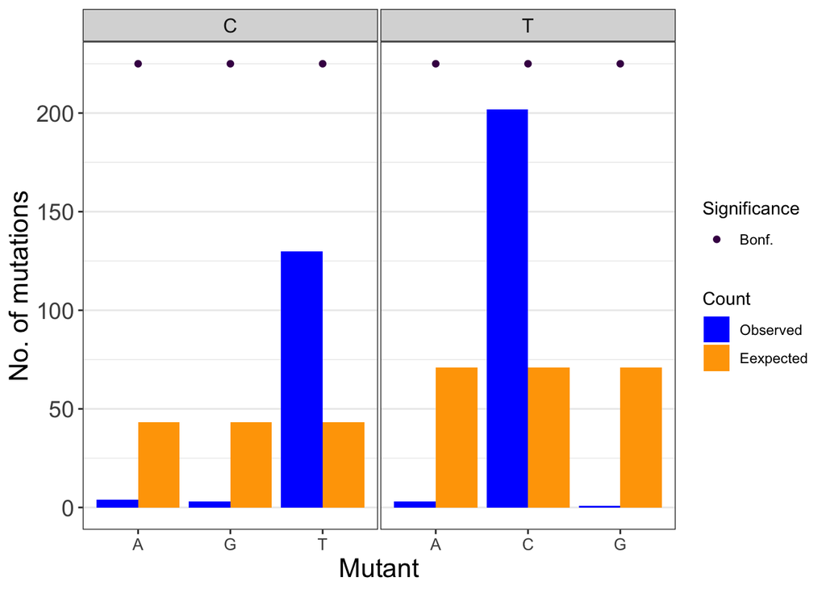

```r
#label mutation type (e.g. C>T)
hq3<-hq2%>%
  mutate(mutation=case_when(ancestral!="undetermined"~paste(ancestral,">",mutant,sep="")))

#group mutations by ancestral allele A/T and G/C together
#summarize number of each mutation type
dhq3<-hq3%>%
  filter(ancestral!="undetermined")%>%
  distinct(FID,position,.keep_all = T)%>%
  group_by(ancestral.py,mutant.py,mutation.py)%>%
  summarize(nhets=length(which(maf>0.01)))

#read reference genome rcrs
rcrs<-read.dna(here("Data_files/rcrs.fasta"),format="fasta")

#summarize base composition in the ref rcrs genome
base.comp<-base.freq(rcrs)*16569
base.comp<-data.frame(base=c("A","T","C","G"),
                      base.comp)

#combine A/T and G/C
base.comp<-base.comp%>%
  mutate(base.py=case_when(base%in%c("A","T")~"T",
                           base%in%c("G","C")~"C"))%>%
  group_by(base.py)%>%
  summarise(base.comp=sum(base.comp))


#add A/T and G/C


dhq3.2<-left_join(dhq3,
            base.comp,
            by=c("ancestral.py"="base.py"))

ddhq3<-dhq3.2%>%
  ungroup()%>%
  mutate(exp.nhets=((base.comp/16569) *sum(nhets))/3)

#perform binomial test to see if any are over/underrepresented
ddhq3$bp<-mapply(FUN=function(a,b){
  if(is.na(a)=="FALSE"&is.na(c)=="FALSE"){
    return(binom.test(x=a,n=343,p=b/343)$p.value)}else{
    return(NA)
  }},
  ddhq3$nhets,
  ddhq3$exp.nhets)
ntests=length(which(is.na(ddhq3$bp)=="FALSE"))
ddhq3<-ddhq3%>%
  mutate(ypos=225,
         sig=case_when(bp<0.05/ntests~"Bonf.",
                       bp>0.05/ntests&bp<0.05~"No. corr.",
                       bp>0.05/ntests~"NS"))

mddhq3<-ddhq3%>%
  select(ancestral.py,mutant.py,mutation.py,
         base.comp,bp,ypos,sig,nhets,exp.nhets)%>%
  melt(id.vars=c("ancestral.py",
                 "mutant.py",
                 "mutation.py","base.comp","ypos","sig","bp"))

plt_spectrum<-ggplot()+
  geom_bar(data=mddhq3,aes(mutant.py,
                 value,
                 fill=variable
                 ),
           stat="identity",
           position="dodge")+
  facet_wrap(~ancestral.py,
             scales="free_x")+
  geom_point(data=ddhq3,aes(mutant.py,
                            ypos,
                            color=sig))+
  theme_bw()+
  theme(panel.grid.major.x = element_blank(),
        axis.text.x=element_text(size=10),
        panel.spacing.x = unit(0.1,"lines"),
        axis.title=element_text(size=16),
        axis.text.y=element_text(size=14),
        strip.text = element_text(size=12))+
  labs(x="Mutant",
       y="No. of mutations",
       fill="Count",
       color="Significance"
       )+
  scale_fill_manual(values=c("blue","orange"),
                          labels=c("Observed",
                                   "Eexpected"))+
  scale_color_viridis_d()

# ggsave(here("Mutation_spectrum/mutation_spectrum_expvobs.pdf"),
#        plt_spectrum,
#        height=3,
#        width=6)

plt_spectrum
```

It seems that the mutation spectrum is heavily skewed. There are more transitions than transversions compared to expectations. Let’s test this formally.

```r
ddhq3<-ddhq3%>%
  mutate(titv=case_when(mutation.py%in%c("C>T","T>C")~"ti",
                        TRUE~"tv"))

ddhq3.ti<-ddhq3%>%
  group_by(titv)%>%
  summarize(nhets=sum(nhets),
            exp.nhet=sum(exp.nhets))

#test whether there are more transitions than transversions
binom.test(x=332,n=343,p=114/343)$p.value
```

```
## [1] 2.94189e-141
```

Summarize the mutation spectrum. Specifically, measure the number of each mutation type observed in our data. A heteroplasmy that exists in multiple samples from the same family is treated as a single mutation (representing a single mutation event).

```r
#summarize for each mutation type and context, the number of observed heteroplasmies
#count a heteroplasmy in each family as independent but only once
dhq<-hq2%>%
  filter(is.na(context.py)=="FALSE")%>%
  distinct(FID,position,.keep_all = T)%>%
  group_by(ancestral,
           mutant,
           mutation,
           context,
    ancestral.py,
           mutant.py,
           mutation.py,
           context.py)%>%
  summarize(nhets=length(which(maf>0.01)))


#change dataframe with all 96 mutation types
mut96<-data.frame(expand.grid(c("A","C","G","T"),
                              c("C>A","C>G","C>T",
                                "T>A","T>C","T>G"),
                              c("A","C","G","T")))

colnames(mut96)<-c("p5","mutation.py","p3")
mut96<-mut96%>%
  group_by(mutation.py)%>%
  mutate(context.py=paste(p5,unlist(strsplit(as.character(mutation.py),split=""))[1],p3,sep=""))

dhq2<-left_join(mut96,dhq,by=c("context.py","mutation.py"))
```

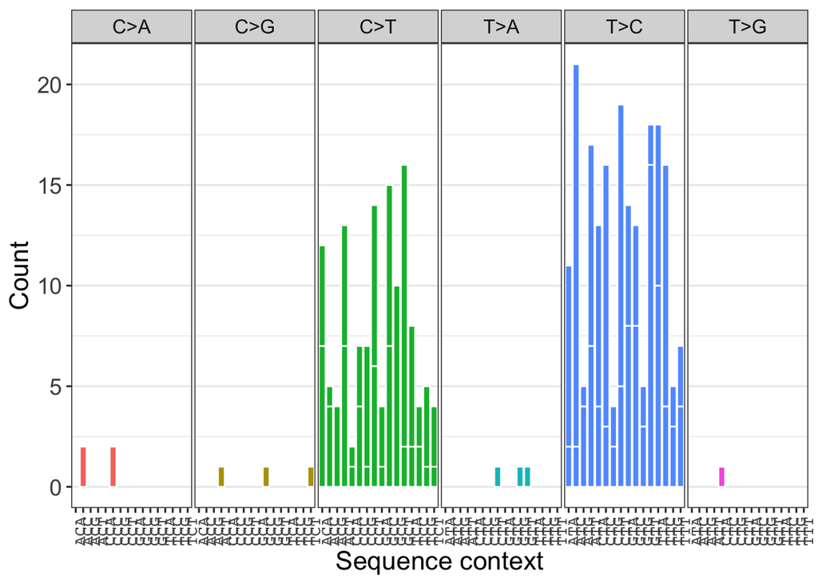

```r
#plot mutation context
context.plt<-ggplot(dhq2,aes(context.py,nhets,
                             fill=mutation.py))+
  geom_bar(stat="identity",color="white")+
  facet_grid(.~mutation.py,scales = "free_x")+
  theme_bw(base_size=12)+
  theme(axis.text.x=element_text(angle=90,family="mono",size=10),
        panel.grid.major.x=element_blank(),
        panel.spacing.x = unit(0.1,"lines"),
        axis.title=element_text(size=16),
        axis.text.y=element_text(size=14),
        strip.text = element_text(size=12),
        legend.position = "none")+
  labs(x="Sequence context",y="Count",fill="Mutation")


#fwrite(hq2,"../../../files/Analysis/syn_nsyn_annotation/hq_adjf_ancestral_annotation_11282018.txt",sep="\t",col.names=T,row.names=F,quote=F)

# ggsave(here("Mutation_spectrum/hq_mutation_context_08172019.pdf"),context.plt,height=4,width=10)

context.plt
```

Finally, let’s normalize sequence context counts by observed composition of triplets in the rcrs genome. To do so, kmerize (k=3) the rCRS genome and count the occurrence of each triplet. Then normalize the observed counts and plot them.

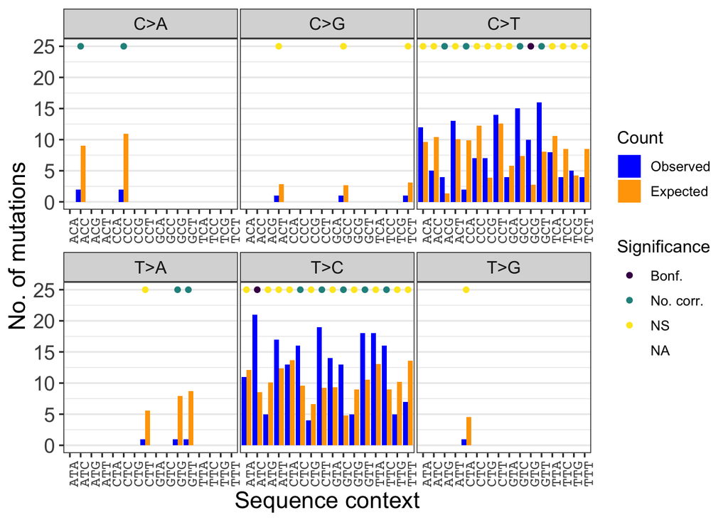

```r
#kmerize the reference genome
#get the number of counts of each triplet in the reference genome
k3<-kcount(rcrs,k=3)
k3<-data.table(triplets=colnames(k3),count=k3[1,])


#add this info to observed heteroplasmy counts
dhq2.k3<-left_join(dhq2,k3,
              by=c("context"="triplets"))

dhq2.k3<-dhq2.k3%>%
  group_by(context.py,
           mutation.py,
           ancestral.py,
           mutant.py)%>%
  summarize(nhets=sum(nhets),
            count=sum(count))

dhq2.k3$total_count=sum(dhq2.k3$count,na.rm=T)

#calculate the expected number of heteroplasmy counts
dhq2.k3<-dhq2.k3%>%
  ungroup()%>%
  mutate(exp.nhets=count/sum(count,na.rm=T)*sum(nhets,na.rm=T))


#perform exact binomial test to test whether expected counts are similar to observed counts

dhq2.k3$bp<-mapply(FUN=function(a,b){
  if(is.na(a)=="FALSE"){
    return(binom.test(x=a,n=343,p=b/343)$p.value)}else{
    return(NA)
  }},
  dhq2.k3$nhets,
  dhq2.k3$exp.nhets
  )

ntests=length(which(is.na(dhq2.k3$bp)=="FALSE"))
dhq2.k3<-dhq2.k3%>%
  mutate(ypos=25,
         sig=case_when(bp<0.05/ntests~"Bonf.",
                       bp>0.05/ntests&bp<0.05~"No. corr.",
                       bp>0.05/ntests~"NS"))

mdhq.k3<-dhq2.k3%>%
  select(mutation.py,
         context.py,
         nhets,
         exp.nhets)%>%
  melt(.,
              id.vars=c("mutation.py",
                        "context.py"))

#plot mutation context
context.plt2<-ggplot(mdhq.k3)+
  geom_bar(aes(context.py,
               value,
               fill=variable),
           stat="identity",
           position="dodge")+
  geom_point(data=dhq2.k3,
             aes(context.py,
                 y=ypos,
                 color=sig))+
  facet_wrap(.~mutation.py,scales = "free_x")+
  theme_bw(base_size=12)+
  theme(axis.text.x=element_text(angle=90,family="mono",size=10),
        panel.grid.major.x=element_blank(),
        panel.spacing.x = unit(0.1,"lines"),
        axis.title=element_text(size=16),
        axis.text.y=element_text(size=14),
        strip.text = element_text(size=12))+
  labs(x="Sequence context",
       y="No. of mutations",
       fill="Count",
       color="Significance")+
  scale_fill_manual(values=c("blue","orange"),
                    labels=c("Observed",
                             "Expected"))+
  scale_color_viridis_d()

#ggsave(here("Mutation_spectrum/hq_mutation_context_08172019.pdf"),context.plt2,height=4,width=7)

context.plt2
```

```r
#combine both plots for supplement
combined_spectrum<-plot_grid(plt_spectrum,
          context.plt2,
          nrow=2,
          ncol=1,rel_heights = c(0.4,0.6))
ggsave(here('combined_spectrum_plot.pdf'),
       combined_spectrum,
       height=7,width=10)
```

Let’s test whether T>C mutations are more frequent than C>T mutations as seems to be the case, when we normalize for the base composition in the reference genome.

```r
ct.muts<-dhq2.k3%>%
  filter(mutation.py%in%c("C>T","T>C"))%>%
  group_by(ancestral.py,mutant.py,mutation.py)%>%
  summarize(nhets=sum(nhets))

ct.muts<-merge(ct.muts,base.comp,
               by.x="ancestral.py",
               by.y="base.py")

ct.muts<-ct.muts%>%
  ungroup()%>%
  mutate(exp.nhets=base.comp/16569 * sum(nhets))

binom.test(130,(332),125.5/332)
```

```
##
##  Exact binomial test
##
## data:  130 and (332)
## number of successes = 130, number of trials = 332, p-value =
## 0.6109
## alternative hypothesis: true probability of success is not equal to 0.378012
## 95 percent confidence interval:
##  0.3387321 0.4463532
## sample estimates:
## probability of success
##              0.3915663
```

Let’s test whether C>T mutations are overrepresented in CpG context.

```r
cpg<-dhq2.k3%>%
  filter(is.na(nhets)=="FALSE" & mutation.py=="C>T")%>%
  mutate(cpg=case_when(context.py%in%c("ACG","TCG","CCG","GCG")~"CpG",
                       TRUE~"non-CpG"))%>%
  group_by(cpg)%>%
  summarize(nhets=sum(nhets),
            exp.nhets=sum(exp.nhets))

cpg
```

```
## # A tibble: 2 x 3
##   cpg     nhets exp.nhets
##   <chr>   <int>     <dbl>
## 1 CpG        26      12.2
## 2 non-CpG   104     114.
```

```r
binom.test(26,130,p=0.107)
```

```
##
##  Exact binomial test
##
## data:  26 and 130
## number of successes = 26, number of trials = 130, p-value =
## 0.001571
## alternative hypothesis: true probability of success is not equal to 0.107
## 95 percent confidence interval:
##  0.1350019 0.2791510
## sample estimates:
## probability of success
##                    0.2
```

C>T mutations are overrepresented in CpG context relative to non-CpG context.

### Synonymous/non-synonymous annotation of heteroplasmies

Based on whether or not a mutation affects the protein sequence, we can annotate it as synonymous or non-synonymous. Also assign each heteroplasmy to a specific gene in the mtDNA.

```r
#mt.code
mt.code<-getGeneticCode("2")

#load genbank file - rcrs annotation for genes
genedb<-fread(here("Data_files/genedb.txt"),header=T)

#filter only coding sequences
genedb2<-genedb%>%
  filter(class=="CDS")

#get vertebrate MT genz

#annotate each heteroplasmy by which gene it's present in
hq$gene<-NA
for(i in 1:nrow(genedb)){
  hq$gene[which(hq$position>=genedb$start[i] & hq$position<=genedb$end[i])]<-genedb$gene[i]
}

#write function to calculate nsyn sites and syn sites for a single codon
nei.sites<-function(codon){
  aa<-Biostrings::translate(DNAString(codon),mt.code)
  codon<-unlist(strsplit(codon,split=""))
  s<-0
  for(k in 1:3){
    nucs<-setdiff(c("a","c","g","t"),codon[k])
    for(l in 1:3){
      mut.codon<-codon
      mut.codon[k]<-nucs[l]
      mt.aa<-Biostrings::translate(DNAString(paste(mut.codon,collapse="")),mt.code)
      if(mt.aa==aa){s<-s+1/3}else{s<-s}
    }
  }
  n<-3-s
  return(c(syn.sites=s,nsyn.sites=n))
}

#write function to return fold degeneracy for a site in a given codon
fold.degeneracy<-function(codon,site){
  aa<-Biostrings::translate(DNAString(codon),mt.code)
  codon<-unlist(strsplit(codon,split=""))
  nucs<-setdiff(c("a","c","g","t"),codon[site])
  s<-1
  for(l in 1:3){
    mut.codon<-codon
    mut.codon[site]<-nucs[l]
    mt.aa<-translate(DNAString(paste(mut.codon,collapse="")),mt.code)
    if(mt.aa==aa){s<-s+1}else{s<-s}
  }
  #if all 3 substitutions are nonsynonymous, site is 4-fold denegerate
  return(s)
}

#calculate a number of things (e.g. fold degeneracy etc.)
hq$hq.gene.pos<-NA
hq$hq.codon.pos<-NA
hq$major.codon<-NA
hq$minor.codon<-NA
hq$major.aa<-NA
hq$minor.aa<-NA
hq$fold.d<-NA
#pb<-txtProgressBar(min=1,max=nrow(hq),style=3)
for(i in 1:nrow(hq)){
  #hq$context.major[i]<-paste(as.character(rcrs[(hq$position[i]-1)]),hq$major[i],as.character(rcrs[(hq$position[i]+1)]),sep="")
  #hq$context.minor[i]<-paste(as.character(rcrs[(hq$position[i]-1)]),hq$minor[i],as.character(rcrs[(hq$position[i]+1)]),sep="")
  gene.name<-hq$gene[i]
  if(gene.name%in%genedb2$gene){
    gene.start<-genedb$start[which(genedb$gene==hq$gene[i])]+1
    gene.end<-genedb$end[which(genedb$gene==hq$gene[i])]
    gene.seq<-as.character(rcrs[(gene.start):(gene.end)])
    gene.strand<-genedb$strand[which(genedb$gene==hq$gene[i])]
    #hq.gene.pos<-hq$position[i]-(gene.start-1)
    if(gene.strand==1){
      hq.gene.pos<-hq$position[i]-(gene.start-1)
      if(hq.gene.pos%%3==0){
        hq.codon<-hq.gene.pos/3
        hq.codon.pos<-3
        hq$hq.codon.pos[i]<-3
        hq.codon.seq<-gene.seq[c(hq.gene.pos-2,hq.gene.pos-1,hq.gene.pos)]
        fold.d<-fold.degeneracy(paste(hq.codon.seq,collapse=""),hq.codon.pos)
      }
      if(hq.gene.pos%%3==1){
        hq.codon<-ceiling(hq.gene.pos/3)
        hq.codon.pos<-1
        hq$hq.codon.pos[i]<-1
        hq.codon.seq<-gene.seq[c(hq.gene.pos,hq.gene.pos+1,hq.gene.pos+2)]
        fold.d<-fold.degeneracy(paste(hq.codon.seq,collapse=""),hq.codon.pos)
      }
      if(hq.gene.pos%%3==2){
        hq.codon<-ceiling(hq.gene.pos/3)
        hq.codon.pos<-2
        hq$hq.codon.pos[i]<-2
        hq.codon.seq<-gene.seq[c(hq.gene.pos-1,hq.gene.pos,hq.gene.pos+1)]
        fold.d<-fold.degeneracy(paste(hq.codon.seq,collapse=""),hq.codon.pos)
      }
      hq.major.seq<-hq.minor.seq<-hq.codon.seq
      hq.major.seq[hq.codon.pos]<-as.character(hq$major[i])
      hq.minor.seq[hq.codon.pos]<-as.character(hq$minor[i])
      hq.major.aa<-as.character(translate(DNAString(paste(hq.major.seq,collapse="")),mt.code))
      hq.minor.aa<-as.character(translate(DNAString(paste(hq.minor.seq,collapse="")),mt.code))

    }
    if(gene.strand== -1){
      gene.seq<-reverseComplement(DNAString(paste(gene.seq,collapse="")))
      gene.seq<-unlist(strsplit(as.character(gene.seq),split=""))
      hq.gene.pos<-gene.end-(hq$position[i]-1)
      if(hq.gene.pos%%3==0){
        hq.codon<-hq.gene.pos/3
        hq.codon.pos<-3
        hq$hq.codon.pos[i]<-3
        hq.codon.seq<-gene.seq[c(hq.gene.pos-2,hq.gene.pos-1,hq.gene.pos)]
        fold.d<-fold.degeneracy(paste(hq.codon.seq,collapse=""),hq.codon.pos)
      }
      if(hq.gene.pos%%3==1){
        hq.codon<-ceiling(hq.gene.pos/3)
        hq.codon.pos<-1
        hq$hq.codon.pos[i]<-1
        hq.codon.seq<-gene.seq[c(hq.gene.pos,hq.gene.pos+1,hq.gene.pos+2)]
        fold.d<-fold.degeneracy(paste(hq.codon.seq,collapse=""),hq.codon.pos)
      }
      if(hq.gene.pos%%3==2){
        hq.codon<-ceiling(hq.gene.pos/3)
        hq.codon.pos<-2
        hq$hq.codon.pos[i]<-2
        hq.codon.seq<-gene.seq[c(hq.gene.pos-1,hq.gene.pos,hq.gene.pos+1)]
        fold.d<-fold.degeneracy(paste(hq.codon.seq,collapse=""),hq.codon.pos)
      }
      hq.major.seq<-hq.minor.seq<-hq.codon.seq
      major<-complement(DNAString(hq$major[i]))
      minor<-complement(DNAString(hq$minor[i]))
      hq.major.seq[hq.codon.pos]<-as.character(major)
      hq.minor.seq[hq.codon.pos]<-as.character(minor)
      hq.major.aa<-as.character(translate(DNAString(paste(hq.major.seq,collapse="")),mt.code))
      hq.minor.aa<-as.character(translate(DNAString(paste(hq.minor.seq,collapse="")),mt.code))
    }
    hq$fold.d[i]<-fold.d
    hq$hq.gene.pos[i]<-hq.gene.pos
    hq$major.codon[i]<-paste(tolower(hq.major.seq),collapse="")
    hq$minor.codon[i]<-paste(tolower(hq.minor.seq),collapse="")
    hq$major.aa[i]<-hq.major.aa
    hq$minor.aa[i]<-hq.minor.aa
  }
  #setTxtProgressBar(pb,i)
}

hq$syn<-NA
hq$syn[which(hq$major.aa==hq$minor.aa)]<-"syn"
hq$syn[which(hq$major.aa!=hq$minor.aa)]<-"nsyn"

#write synonymous and non-synonymous information
hq.syn<-hq%>%
  select(FID,fqid,position,fq_het_id,major,minor,maf,run,gene,hq.gene.pos,hq.codon.pos,major.codon,minor.codon,major.aa,minor.aa,syn,fold.d,ancestral,mutant,context,ancestral.py,mutant.py,context.py)

# fwrite(hq,
#        here("Data_files/hq_adjf_ancestral_syn_11282018.txt"),
#        sep="\t",
#        col.names=T,
#        row.names=F,quote=F)
```

Calculate no. of synonymous and non-synonymous heteroplasmies in each gene in our data.

```r
#calculate total number of syn/nsyn mutations in every gene
dhq.syn<-as.data.frame(hq.syn%>%
  filter(duplicated(fq_het_id)=="FALSE" & gene%in%genedb2$gene)%>%
  group_by(gene,syn)%>%
  summarize(nhets=length(FID)))

#COX2 has no non-synonymous changes - add row for plotting/calculations
dhq.syn<-rbind(dhq.syn,data.frame(gene="COX2",syn="nsyn",nhets=0))
#add rcrs for plotting
rcrs_syn=sum(dhq.syn$nhets[which(dhq.syn$syn=="syn")])
rcrs_nsyn=sum(dhq.syn$nhets[which(dhq.syn$syn=="nsyn")])

dhq.syn<-rbind(dhq.syn,data.frame(gene=c("rcrs","rcrs"),syn=c("nsyn","syn"),nhets=c(rcrs_nsyn,rcrs_syn)))

#calculate total number of mutations by mutation type in coding sequences
hq.spectrum<-hq.syn%>%
  filter(duplicated(fq_het_id)=="FALSE" &
           gene%in%genedb2$gene &
           is.na(ancestral)=="FALSE")%>%
  group_by(gene,ancestral,mutant)%>%
  summarize(nhets=length(FID))
```

Now, calculate number of synonymous and non-synonymous sites in each gene.

```r
#calculate no. of syn and nysn sites in mtDNA
genedb2$syn.sites<-NA
genedb2$nsyn.sites<-NA

#apply this function to all codons for every gene
for(i in 1:nrow(genedb2)){
  gene.start<-genedb2$start[i]+1
  gene.end<-genedb2$end[i]
  gene.seq<-as.character(rcrs[c(gene.start:gene.end)])
  if(genedb2$strand[i]==1){gene.seq<-gene.seq}
  if(genedb2$strand[i]==-1){
    gene.seq<-tolower(unlist(strsplit(as.character(reverseComplement(DNAString(paste(gene.seq,collapse="")))),split="")))}
  if(length(gene.seq)%%3==0){
    gene.seq<-gene.seq
  }
  if(length(gene.seq)%%3==1){
    gene.seq<-c(gene.seq,"a","a")
  }
  if(length(gene.seq)%%3==2){
    gene.seq<-c(gene.seq,"a")
  }
  gene.codons<-seqinr::splitseq(gene.seq,0,3)
  #print(genedb2$gene[i])

  nsites<-sapply(gene.codons,nei.sites)
  nsites<-apply(nsites,1,sum)
  genedb2$syn.sites[i]<-nsites[1]
  genedb2$nsyn.sites[i]<-nsites[2]
  genedb2$seq[i]<-paste(gene.seq,collapse="")
}

#convert genedb2 to long format for plotting and merging with hq object
dgenedb.syn<-genedb2%>%
  select(gene,syn.sites,nsyn.sites)%>%
  melt(id.vars="gene",variable.name="synonymity",value.name="nsites")%>%
  mutate(syn=case_when(synonymity=="syn.sites"~"syn",
                       synonymity=="nsyn.sites"~"nsyn"))

#add rcrs to dgene.db
rcrs_ssites<-sum(dgenedb.syn$nsites[which(dgenedb.syn$syn=="syn")])
rcrs_nsites<-sum(dgenedb.syn$nsites[which(dgenedb.syn$syn=="nsyn")])

dgenedb.syn<-rbind(dgenedb.syn,data.frame(gene=c("rcrs","rcrs"),
                                          synonymity=c("nsyn.sites","syn.sites"),
                                          nsites=c(rcrs_nsites,rcrs_ssites),
                                          syn=c("nsyn","syn")))

#merged dhq.syn and dgenedb.syn
dmerged<-merge(dhq.syn,dgenedb.syn,by=c("gene","syn"))
```

Calculate hN/hS - where hN is the ratio of the observed number of non-synonymous heteroplasmies and the number of non-synonymous sites. hS is the ratio of the observed number of synonymous heteroplasmies and the number of synonymous sites. hN/hS=1 is the neutral expectation.

```r
#calculate hN/hS
dmerged<-dmerged%>%
  mutate(prop=nhets/nsites)%>%
  mutate(k=prop)
  #mutate(k=-0.75*log(1- (4/3 * prop)))

mdmerged<-dmerged%>%
  dcast(gene~syn,value.var="k")%>%
  mutate(hn_hs=nsyn/syn)
```

To test whether the observed values of hN/hS are significantly different from 1, we used a bootstrap method from Stoneking paper (Li 2015). The algorithm is as follows:

1. Calculate the observed distribution of heteroplasmies per mutation type (e.g. A>G observed 9 times, C>T observed 4 times etc.)
2. ‘Mutate’ the rCRS using this spectrum of heteroplasmis. For example, mutate 9 randomly picked As to Gs because that’s how many A>G mutations were observed.
3. Calculate hN/hS.
4. Repeat steps 2 and 3 1,000 times to generate a null distribution for hN/hS.

```r
genedb3<-genedb2%>%
  filter(gene!="ND4L")

#define function to do this for each gene
dnds.boot<-function(gn){
  if(gn=="rcrs"){
    total_mutations=sum(hq.spectrum$nhets)
    #concatenate all coding sequences
    gene_seq=unlist(strsplit(paste(genedb3$seq,collapse=""),split=""))
    #create mutated sequence
    mut_seq=gene_seq
    hq_spec=hq.spectrum%>%
      group_by(ancestral,mutant)%>%
      summarize(nhets=sum(nhets))
    syn_sites=sum(genedb3$syn.sites)
    nsyn_sites=sum(genedb3$nsyn.sites)

  }
  else{
  db<-genedb3%>%
    filter(gene==gn)

  hq_spec=hq.spectrum%>%
    filter(gene==gn)

  total_mutations=sum(hq_spec$nhets)

  gene_seq<-unlist(strsplit(db$seq,split=""))
  mut_seq=gene_seq
  nsyn_sites=db$nsyn.sites
  syn_sites=db$syn.sites
  }

  for(i in 1:nrow(hq_spec)){
    sites=which(gene_seq==tolower(hq_spec$ancestral[i]))
    nmutations=hq_spec$nhets[i]
    #randomly sample these many sites to mutate
    mut_sites=sample(sites,nmutations)
    mut_seq[mut_sites]=tolower(hq_spec$mutant[i])
  }

  anc_codons<-seqinr::splitseq(gene_seq,0,3)
  mut_codons<-seqinr::splitseq(mut_seq,0,3)

  #dissimilar codons
  anc_mismatch=paste(anc_codons[which(anc_codons!=mut_codons)],collapse="")
  mut_mismatch=paste(mut_codons[which(anc_codons!=mut_codons)],collapse="")


  anc_aa<-unlist(strsplit(as.character(translate(DNAString(anc_mismatch),genetic.code = mt.code)),split=""))
  mut_aa<-unlist(strsplit(as.character(translate(DNAString(mut_mismatch),genetic.code = mt.code)),split=""))

  nsyn=length(which(anc_aa!=mut_aa))
  syn=total_mutations-nsyn

  #ka=-0.75*log(1- (4/3 * (nsyn/nsyn_sites)))
  #ks=-0.75*log(1- (4/3 * (syn/syn_sites)))
  hn=nsyn/nsyn_sites
  hs=syn/syn_sites
  hn_hs=hn/hs
  return(hn_hs)

}

#calculate neutral distribution for every gene and the whole rcrs coding sequence
gene_list=c("rcrs",unique(genedb3$gene))
dnds_bootmat=matrix(NA,nrow=1000,ncol=length(gene_list))
for(j in 1:length(gene_list)){
  dnds_bootmat[,j]<-replicate(1000,dnds.boot(gene_list[j]))
  #print(gene_list[j])
}

colnames(dnds_bootmat)<-gene_list
dnds_bootmat<-as_data_frame(dnds_bootmat)

mdnds_bootmat<-melt(dnds_bootmat,variable.name="Gene",value.name="dn_ds")
```

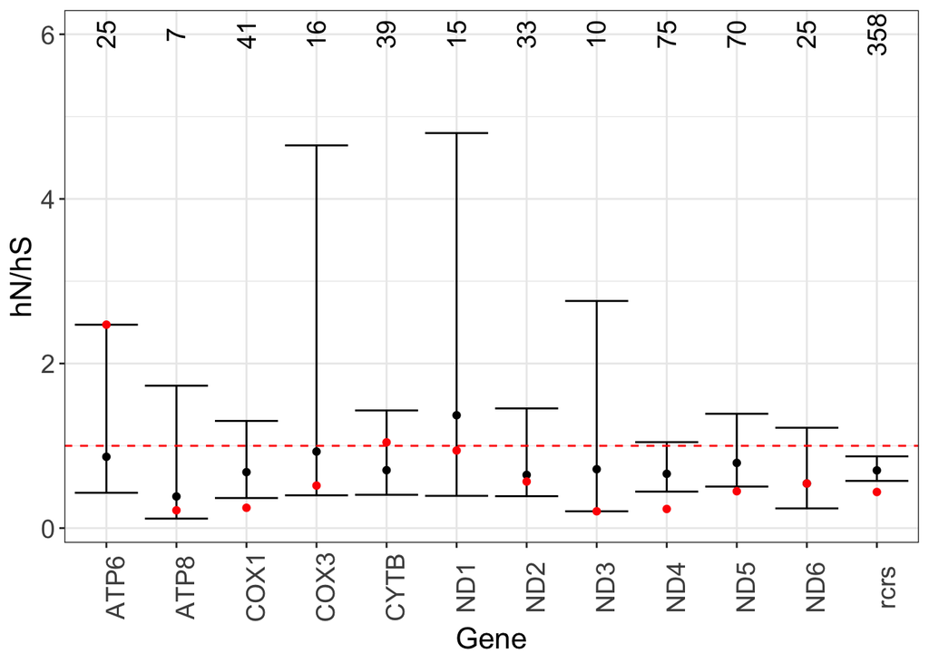

```r
#generate 95% confidence interval from bootstrap data
#remove COX2 because it only has 2 heteroplasmies
mdnds_summary<-mdnds_bootmat%>%
  filter(Gene!="COX2")%>%
  group_by(Gene)%>%
  summarize(median=median(dn_ds),
            lower=quantile(dn_ds,probs=0.025),
            upper=quantile(dn_ds,probs=0.975))

#calculate number of heteroplasmies observed in each gene
nhq_gene<-hq.spectrum%>%
  filter(gene!="COX2")%>%
  group_by(gene)%>%
  summarize(nhets=sum(nhets))
nhq_gene<-rbind(nhq_gene,
                data.frame(gene="rcrs",nhets=sum(hq.spectrum$nhets)))

plt_hnhs<-ggplot(mdnds_summary)+
  geom_point(aes(Gene,median))+
  geom_errorbar(aes(Gene,ymin=lower,ymax=upper))+
  theme_bw()+
  theme(axis.text.x=element_text(angle=90,
                                 size=14),
        axis.text.y=element_text(size=14),
        axis.title=element_text(size=16),
        text=element_text(size=14))+
  labs(x="Gene",y="hN/hS")+
  geom_point(data=mdmerged[which(mdmerged!="COX2"),],aes(gene,hn_hs),color="red")+
  geom_text(data=nhq_gene,aes(x=gene,y=6,label=nhets),angle=90,size=5)+
  geom_hline(yintercept = 1,linetype="dashed",color="red")

plt_hnhs
```

What is the p-value for the hN/hS test across the whole mtDNA coding sequence?

```r
mdnds_bootmat%>%
  filter(Gene=="rcrs")%>%
  summarize(pvalue=length(which(dn_ds<0.43))/length(dn_ds))
```

```
##   pvalue
## 1      0
```

```r
#save the previous plot
# ggsave("~/Documents/mtproj_files/M2_new/files/Analysis/mutation_spectrum/hnhs_distribution.pdf",plt_hnhs,height=5,width=5,useDingbats=F)
```

### Distribution of mtDNA mutations

Plot the distribution of mutations along mtDNA. Each point is an independent mutation event, assuming heteroplasmies at a site in a family are the result of a single mutation.

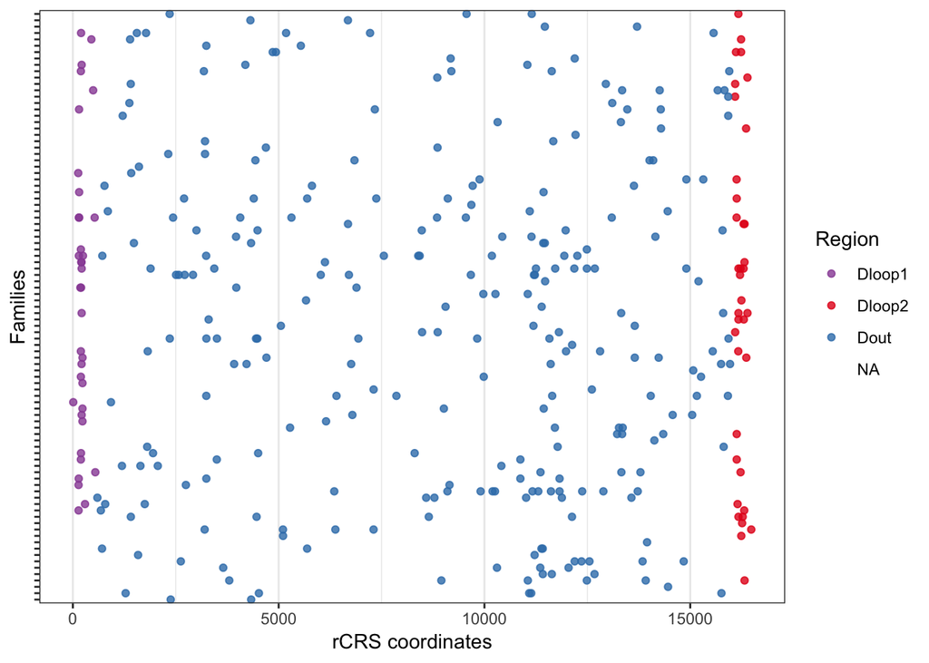

```r
dhq.number<-hq%>%
  distinct(fam_het_id,.keep_all = T)


genedb<-genedb%>%
  mutate(region=case_when(gene=="D-loop1"~"Dloop1",
                          gene=="D-loop2"~"Dloop2",
                          !gene%in%c("D-loop1","D-loop2")~"Dout"))

mtdna.dat<-merge(dhq.number,genedb,by="gene",all.x=T)


genedb<-genedb%>%
  mutate(cols=case_when(class=="Dloop"~"#e41a1c",
                        class=="CDS"~"#ff7f00",
                        class=="tRNA"~"#4daf4a",
                        class=="rRNA"~"#984ea3"))

p1<-ggplot(mtdna.dat)+
  geom_point(alpha=0.8,size=1.5,aes(position,FID,color=region))+
  theme_bw()+
  theme(axis.text.y=element_blank(),panel.grid.major.y = element_blank())+
  scale_shape_manual(values=c(1,19))+
  scale_color_manual(values=c("#984ea3","#e41a1c","#377eb8","#ff7f00"))+
  labs(y="Families",x="rCRS coordinates",color="Region")

p1
```